# Topic 4 Exercises: Classification

# Programming Assignment

4.7.11

```r
library(ISLR)
Auto
```

```
##      mpg cylinders displacement horsepower weight acceleration year origin
## 1   18.0         8        307.0        130   3504         12.0   70      1
## 2   15.0         8        350.0        165   3693         11.5   70      1
## 3   18.0         8        318.0        150   3436         11.0   70      1
## 4   16.0         8        304.0        150   3433         12.0   70      1
## 5   17.0         8        302.0        140   3449         10.5   70      1
## 6   15.0         8        429.0        198   4341         10.0   70      1
## 7   14.0         8        454.0        220   4354          9.0   70      1
## 8   14.0         8        440.0        215   4312          8.5   70      1
## 9   14.0         8        455.0        225   4425         10.0   70      1
## 10  15.0         8        390.0        190   3850          8.5   70      1
## 11  15.0         8        383.0        170   3563         10.0   70      1
## 12  14.0         8        340.0        160   3609          8.0   70      1
## 13  15.0         8        400.0        150   3761          9.5   70      1
## 14  14.0         8        455.0        225   3086         10.0   70      1
```

[output cut: 771 more lines]

```r
Auto$mpg01=0
Auto$mpg01[Auto$mpg < 23]=1
list(Auto$mpg01)
```

```
## [[1]]
##   [1] 1 1 1 1 1 1 1 1 1 1 1 1 1 1 0 1 1 1 0 0 0 0 0 0 1 1 1 1 1 0 0 0 1 1 1
##  [36] 1 1 1 1 1 1 1 1 1 1 1 1 1 0 0 0 0 0 0 0 0 0 0 0 1 1 1 1 1 1 1 1 1 1 1
##  [71] 1 1 1 1 1 1 1 1 0 1 0 0 0 0 1 1 1 1 1 1 1 1 1 1 1 1 1 1 1 1 0 0 1 1 1
## [106] 1 1 1 1 1 1 1 1 0 1 1 0 0 1 1 1 0 1 1 1 1 1 0 0 0 0 1 1 1 1 1 1 1 1 0
## [141] 0 0 0 0 0 0 0 0 0 0 1 1 1 1 1 1 1 1 1 1 1 1 1 1 1 0 0 1 0 0 0 0 1 0 1
## [176] 0 0 1 0 0 0 0 0 0 0 1 1 1 1 1 1 0 1 0 0 0 0 1 1 1 1 0 0 0 0 1 1 1 1 1
## [211] 1 1 1 1 0 0 0 0 0 1 1 1 1 1 1 1 1 1 1 1 1 0 0 0 0 0 0 0 0 1 1 1 0 0 0
## [246] 0 0 1 1 1 1 1 1 0 1 1 1 1 1 1 1 1 1 1 0 0 0 0 1 0 0 0 1 1 1 1 0 0 1 1
## [281] 1 1 1 1 1 1 1 1 1 1 1 0 0 0 0 0 0 0 0 0 0 0 0 0 0 0 0 0 0 0 0 0 0 0 1
## [316] 0 0 0 0 0 0 0 0 0 0 0 0 0 0 0 0 0 0 0 0 0 0 0 0 0 0 0 0 0 0 0 0 0 0 0
## [351] 0 0 0 0 0 0 0 0 1 0 1 1 0 0 0 0 0 0 0 0 0 0 0 0 0 0 0 0 0 0 0 0 0 1 0
## [386] 0 0 0 0 0 0 0
```

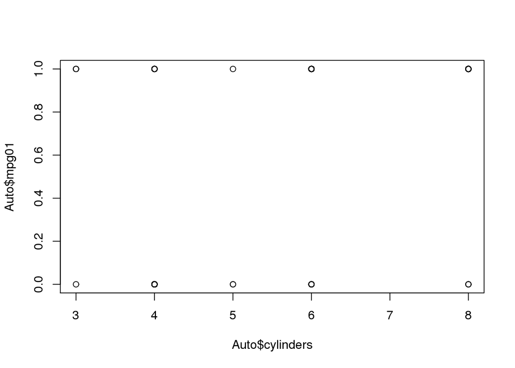

```r
plot(Auto$cylinders,Auto$mpg01)
```

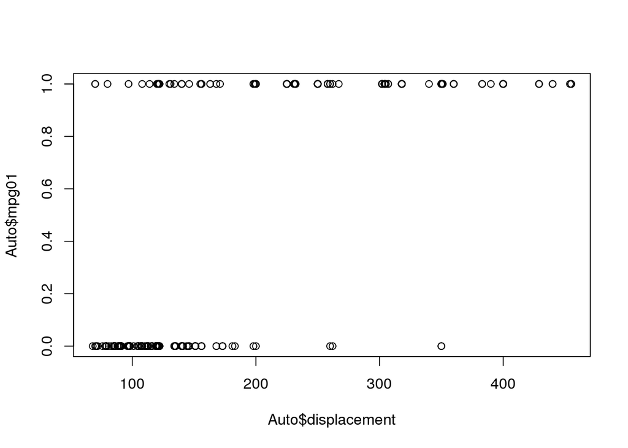

```r
plot(Auto$displacement,Auto$mpg01)
```

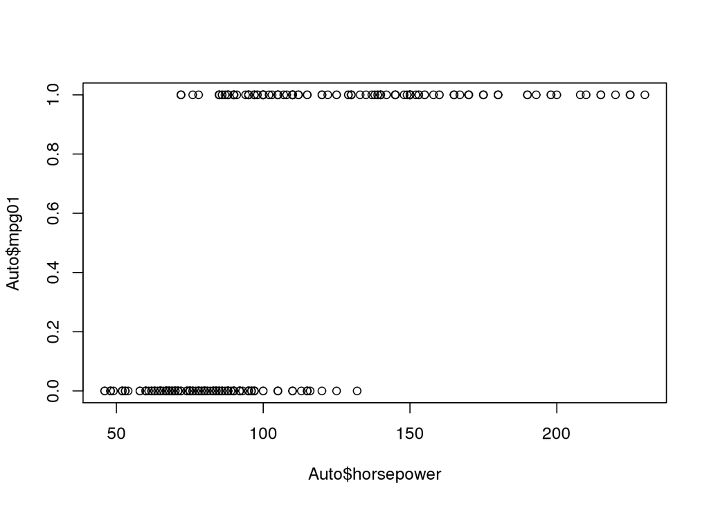

```r
plot(Auto$horsepower,Auto$mpg01)
```

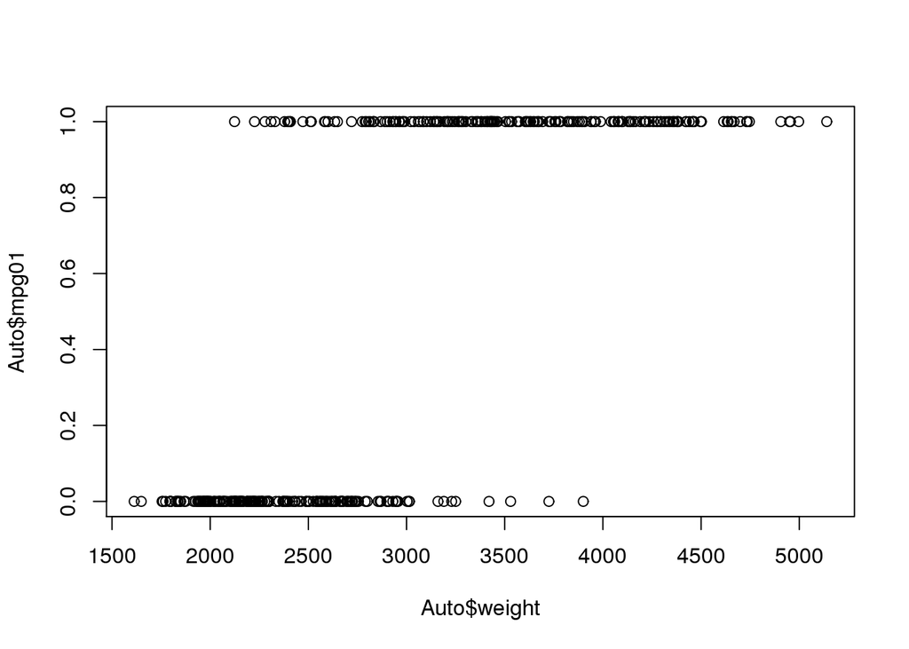

```r
plot(Auto$weight,Auto$mpg01)
```

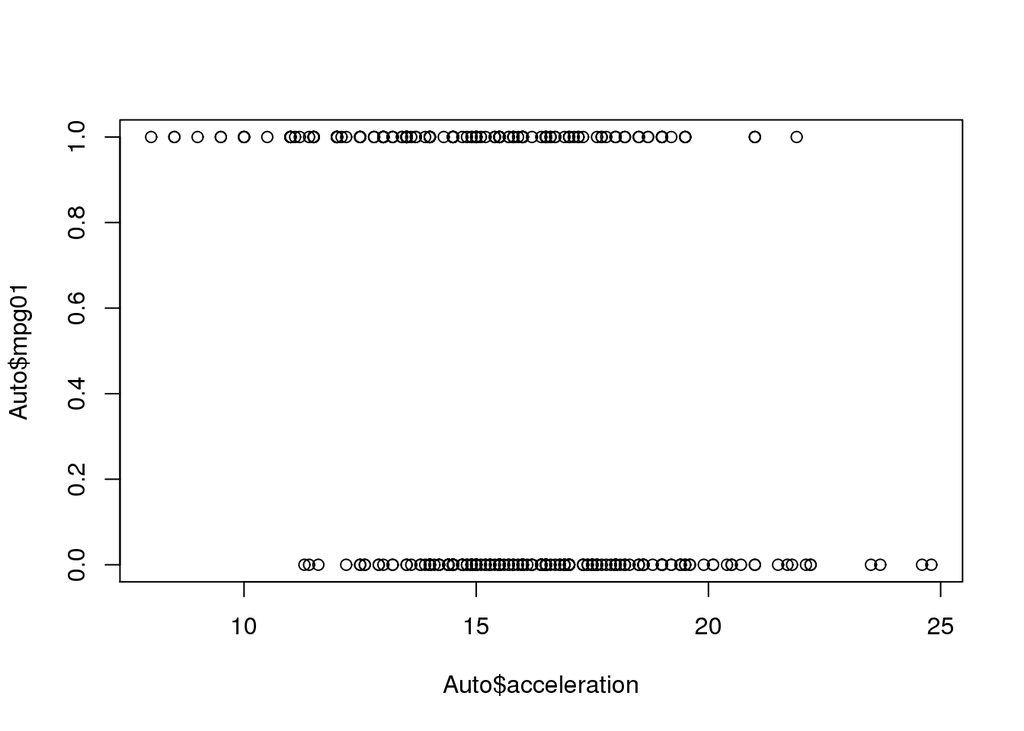

```r
plot(Auto$acceleration,Auto$mpg01)
```

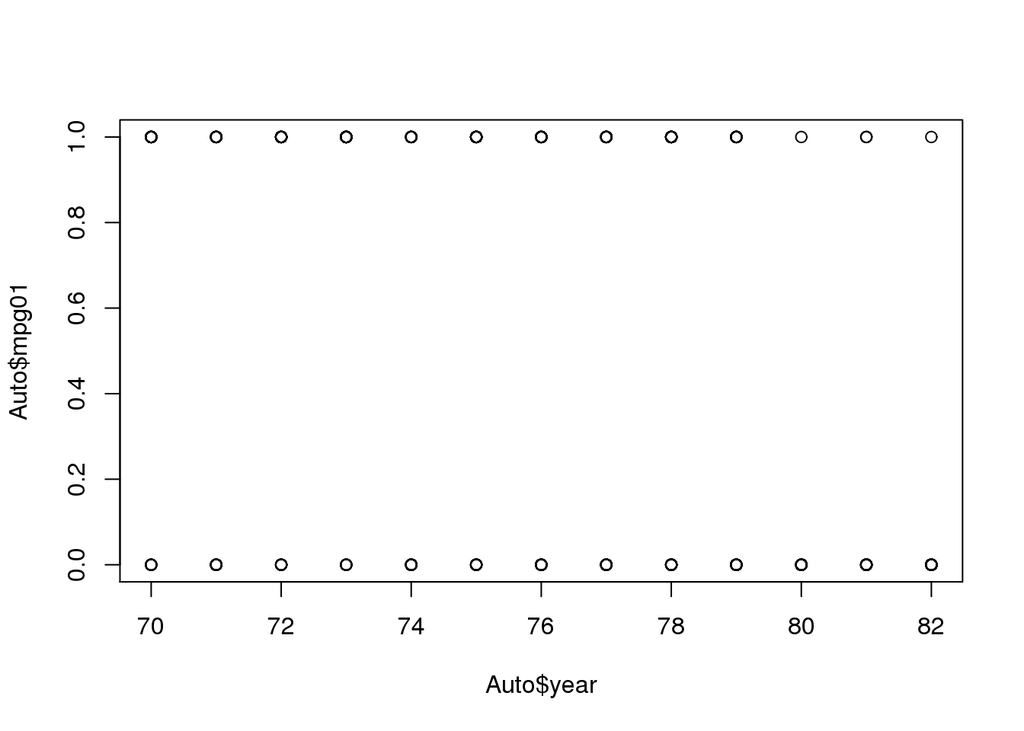

```r
plot(Auto$year,Auto$mpg01)
```

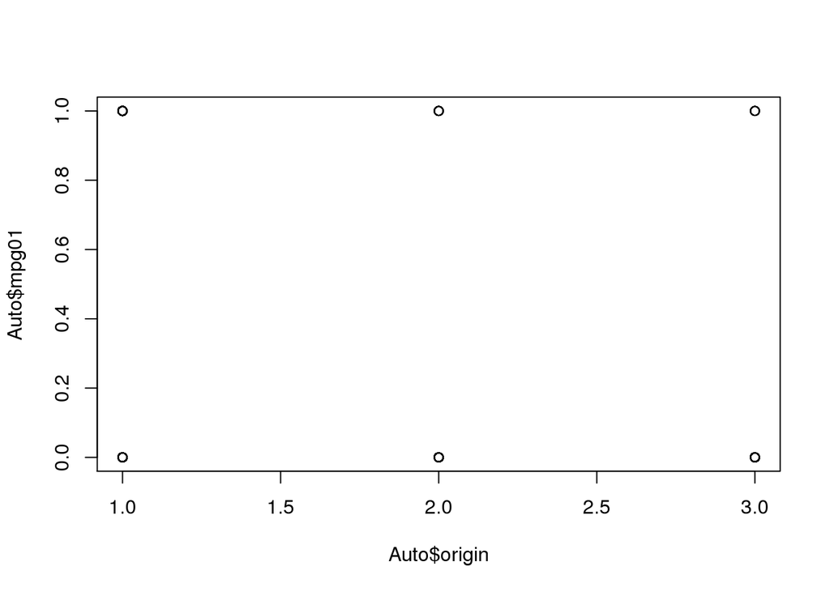

```r
plot(Auto$origin,Auto$mpg01)
```

Based on scatter plots of the various features versus our new dummy variable mpg01, it seems as though weight is the best predictor.

```r
train = (Auto$year%%2 == 0)  # if the year is even
test = !train
Auto.train = Auto[train, ]
Auto.test = Auto[test, ]
mpg01.test = Auto.test$mpg01
```

```r
library(MASS)
lda.fit = lda(mpg01 ~ acceleration + weight + displacement +cylinders , data = Auto.train)
lda.pred = predict(lda.fit, Auto.test)
mean(lda.pred$class != mpg01.test)
```

```
## [1] 0.1208791
```

12.1% error rate

```r
qda.fit = qda(mpg01 ~ cylinders + weight + displacement , data = Auto.train)
qda.pred = predict(qda.fit, Auto.test)
mean(qda.pred$class != mpg01.test)
```

```
## [1] 0.1208791
```

12.1% error rate

```r
glm.fit = glm(mpg01 ~ cylinders + weight + displacement , data = Auto.train, family = binomial)
glm.probs = predict(glm.fit, Auto.test, type = "response")
glm.pred = rep(0, length(glm.probs))
glm.pred[glm.probs > 0.5] = 1
mean(glm.pred != mpg01.test)
```

```
## [1] 0.1428571
```

14.28% error rate

```r
library(class)
train.X = as.matrix(Auto.train$cylinders, Auto.train$weight, Auto.train$displacement)
test.X = as.matrix(Auto.test$cylinders, Auto.test$weight, Auto.test$displacement)
train.mpg01 = Auto.train$mpg01
train.mpg01
```

```
##   [1] 1 1 1 1 1 1 1 1 1 1 1 1 1 1 0 1 1 1 0 0 0 0 0 0 1 1 1 1 1 0 0 0 1 1 1
##  [36] 1 1 1 1 1 1 1 1 1 1 1 1 1 1 1 1 0 1 0 0 0 0 1 1 1 0 0 0 0 1 1 1 1 1 1
##  [71] 1 1 0 0 0 0 0 0 0 0 0 0 0 0 0 0 0 0 1 1 1 1 1 1 0 1 0 0 0 0 1 1 1 1 0
## [106] 0 0 0 1 1 1 1 1 1 1 1 1 0 0 0 0 0 1 1 1 1 1 1 0 1 1 1 1 1 1 1 1 1 1 0
## [141] 0 0 0 1 0 0 0 1 1 1 1 0 0 0 0 0 0 0 0 0 1 0 0 0 0 0 0 0 0 0 0 0 0 0 0
## [176] 0 0 0 0 0 0 0 0 0 0 0 0 0 0 0 0 0 0 0 0 0 0 0 0 0 0 1 0 0 0 0 0 0 0 0
```

```r
set.seed(1)
# KNN(k=1)
knn.pred = knn(train.X, test.X, train.mpg01, k = 1)
mean(knn.pred != mpg01.test)
```

```
## [1] 0.1153846
```

```r
# KNN(k=10)
knn.pred = knn(train.X, test.X, train.mpg01, k = 10)
mean(knn.pred != mpg01.test)
```

```
## [1] 0.1208791
```

```r
# KNN(k=100)
knn.pred = knn(train.X, test.X, train.mpg01, k = 100)
mean(knn.pred != mpg01.test)
```

```
## [1] 0.5494505
```

```r
# KNN(k=200)
knn.pred = knn(train.X, test.X, train.mpg01, k = 200)
mean(knn.pred != mpg01.test)
```

```
## [1] 0.5494505
```

4.7.13

```r
library(MASS)
Boston
```

```
##         crim    zn indus chas    nox    rm   age     dis rad tax ptratio
## 1    0.00632  18.0  2.31    0 0.5380 6.575  65.2  4.0900   1 296    15.3
## 2    0.02731   0.0  7.07    0 0.4690 6.421  78.9  4.9671   2 242    17.8
## 3    0.02729   0.0  7.07    0 0.4690 7.185  61.1  4.9671   2 242    17.8
## 4    0.03237   0.0  2.18    0 0.4580 6.998  45.8  6.0622   3 222    18.7
## 5    0.06905   0.0  2.18    0 0.4580 7.147  54.2  6.0622   3 222    18.7
## 6    0.02985   0.0  2.18    0 0.4580 6.430  58.7  6.0622   3 222    18.7
## 7    0.08829  12.5  7.87    0 0.5240 6.012  66.6  5.5605   5 311    15.2
## 8    0.14455  12.5  7.87    0 0.5240 6.172  96.1  5.9505   5 311    15.2
## 9    0.21124  12.5  7.87    0 0.5240 5.631 100.0  6.0821   5 311    15.2
## 10   0.17004  12.5  7.87    0 0.5240 6.004  85.9  6.5921   5 311    15.2
## 11   0.22489  12.5  7.87    0 0.5240 6.377  94.3  6.3467   5 311    15.2
## 12   0.11747  12.5  7.87    0 0.5240 6.009  82.9  6.2267   5 311    15.2
## 13   0.09378  12.5  7.87    0 0.5240 5.889  39.0  5.4509   5 311    15.2
## 14   0.62976   0.0  8.14    0 0.5380 5.949  61.8  4.7075   4 307    21.0
```

[output cut: 999 more lines]

```r
crime01 = rep(0, length(Boston$crim))
crime01[Boston$crim > median(Boston$crim)] = 1
Boston = data.frame(Boston, crime01)


Btrain = 1:(dim(Boston)[1]/2)
Btest = (dim(Boston)[1]/2 + 1):dim(Boston)[1]
Boston.train = Boston[Btrain, ]
Boston.test = Boston[Btest, ]
crime01.test = crime01[Btest]
```

Logistic

```r
glm.fit = glm(crime01 ~ . - crime01 - crim, data = Boston.train, family = binomial)
glm.probs = predict(glm.fit, Boston.test, type = "response")
glm.pred = rep(0, length(glm.probs))
glm.pred[glm.probs > 0.5] = 1
mean(glm.pred != crime01.test)
```

```
## [1] 0.1818182
```

```r
glm.fit = glm(crime01 ~ . - crime01 - crim - chas - tax, data = Boston.train, family = binomial)
glm.probs = predict(glm.fit, Boston.test, type = "response")
glm.pred = rep(0, length(glm.probs))
glm.pred[glm.probs > 0.5] = 1
mean(glm.pred != crime01.test)
```

```
## [1] 0.1857708
```

18.18% error for complex models, 18.58% error for simple models

LDA

```r
lda.fit = lda(crime01 ~ . - crime01 - crim, data = Boston.train)
lda.pred = predict(lda.fit, Boston.test)
mean(lda.pred$class != crime01.test)
```

```
## [1] 0.1343874
```

```r
lda.fit = lda(crime01 ~ . - crime01 - crim - chas - tax - lstat - indus - age,
    data = Boston.train)
lda.pred = predict(lda.fit, Boston.test)
mean(lda.pred$class != crime01.test)
```

```
## [1] 0.1185771
```

13.44% error for complex models, 11.86% error for simple models

KNN

```r
library(class)
train.BX = as.matrix(Boston.train$zn, Boston.train$indus, Boston.train$chas, Boston.train$nox, Boston.train$rm, Boston.train$age, Boston.train$dis, Boston.train$rad, Boston.train$tax, Boston.train$ptratio, Boston.train$black,
    Boston.train$lstat, Boston.train$medv)
test.BX = as.matrix(Boston.test$zn, Boston.test$indus, Boston.test$chas, Boston.test$nox, Boston.test$rm, Boston.test$age, Boston.test$dis, Boston.test$rad, Boston.test$tax, Boston.test$ptratio, Boston.test$black,Boston.test$lstat, Boston.test$medv)
train.crime01 = Boston.train$crime01
set.seed(1)
#(k=1)
knn.pred = knn(train.BX, test.BX, train.crime01, k = 1)
mean(knn.pred != crime01.test)
```

```
## [1] 0.6442688
```

```r
#(k=10)
knn.pred = knn(train.BX, test.BX, train.crime01, k = 10)
mean(knn.pred != crime01.test)
```

```
## [1] 0.6442688
```

```r
#(k=100)
knn.pred = knn(train.BX, test.BX, train.crime01, k = 100)
mean(knn.pred != crime01.test)
```

```
## [1] 0.6442688
```

For K=1,k=10,k=100, error rate=64.43%

## Theory assignment

4.7.1

Prove that the logistic function representation (4.2) and logit representation (4.3) for logistic regression model are equivalent.

p(x)=exp{Bo+B1X}/(1+exp{Bo+B1X}) 1-exp{Bo+B1X}/(1+exp{Bo+B1X})=exp{Bo+B1X}/(1+exp{Bo+B1X}) p(x)=exp{Bo+B1X}/(1+exp{Bo+B1X})/(1-exp{Bo+B1X}/(1+exp{Bo+B1X})) p(x)=exp{Bo+B1X}/(1+exp{Bo+B1X})/(1/(1+exp{Bo+B1X})) p(x)/(1-p(x))=exp{Bo+B1X}/(1+exp{Bo+B1X})

4.7.8

For KNN with k=1, the training error rate will always be 0%. Therefore, a KNN with an average error rate of 18% between training and test will have a test error rate of 36%. Since we’re looking for the method with the lowest test error rate, I would choose the logistic regression, since it’s error rate of 30% is lower.

4.7.9

1. p(x)/(1-p(x))=0.37 p(x)=0.37(1-p(x)) p(x)=0.37-0.37p(x) 1.37p(x)=0.37 p(x)=0.27 27% of people will default
2. p(x)=0.16 p(x)/(1-p(x))=odds 0.16/(1-0.16)=odds odds=0.19